```python
%matplotlib inline
import seaborn as sns
sns.set_context('talk')
```

# Temperature conversion

- In the new simulations, I use temperature dependent mean molecular weight $\mu(T)$.
- To do so, I read a table for CIE cooling from SD93.

## CIE cooling in Sutherland & Dopita (1993; SD93)

### From Abundance Table (Table 4)

| Spicies | -log($n_i/n_H$) | Z_i | A_i |  | Spicies | -log($n_i/n_H$) | Z_i | A_i |
| --- | --- | --- | --- | --- | --- | --- | --- | --- |
| H | 0.0 | 1 | 1 |  | He | -1.01 | 2 | 4 |
| C | -3.44 | 6 | 12 |  | N | -3.95 | 7 | 14 |
| O | -3.07 | 8 | 16 |  | Ne | -3.91 | 10 | 20.2 |
| Na | -5.67 | 11 | 23 |  | Mg | -4.42 | 12 | 24.3 |
| Al | -5.53 | 13 | 27 |  | Si | -4.45 | 14 | 28.1 |
| S | -4.79 | 16 | 32.1 |  | Cl | -6.5 | 17 | 35.5 |
| Ar | -5.44 | 18 | 39.9 |  | Ca | -5.64 | 20 | 40.1 |
| Fe | -4.33 | 26 | 55.8 |  | Ni | -5.75 | 28 | 58.7 |

```python
n=10.**np.array([0.0, -1.01, -3.44, -3.95, -3.07, -3.91, -5.67, -4.42, -5.53, -4.45, -4.79, -6.5, -5.44, -5.64, -4.33, -5.75])
A=np.array([1,4, 12, 14, 16, 20.2, 23, 24.3, 27, 28.1, 32.1, 35.5, 39.9, 40.1, 55.8, 58.7])
Z=np.array([1,2,6,7,8,10,11, 12, 13, 14, 16, 17, 18, 20, 26, 28])
print (n*A).sum()/n.sum()
print (n*A).sum()/(n*(1+Z)).sum()
print (n*A).sum()/n[0]
```

```
1.29030226288
0.614468922737
1.41845865019
```

- atomic gas $$\mu=\sum n_i A_i / \sum n_i \approx 1.2903$$
- fully ionized gas $$\mu=\sum n_i A_i / \sum n_i(1+Z_i) \approx0.6145$$
- $$\mu_H = \sum n_i A_i / n_H \approx 1.4185$$

### From Table 6 (this is what I used for mean molecular weights)

- atomic ($\log(T)<4$): $\mu = 1.295$
- fully ionized ($\log(T)>5.5$): $\mu = 0.6182$
- $\mu_H=1.4271$
- Small descrepancy between the values here and Table 4 (above) may arise from $Z_i$ and $A_i$ I read in from a periodic table.

```
Index([u'log(T)', u'ne', u'nH', u'nt', u'log(lambda net)', u'log(lambda norm)',
       u'log(U)', u'log(taucool)', u'P12', u'rho24', u'Ci', u'mubar'],
      dtype='object')
1.29497297583 0.618191162054
1.4271008741
```

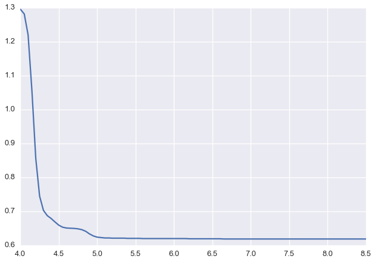

```python
f='m-00.cie'
import pandas as pd
df=pd.read_table(f,header=1)
print df.columns

mu_SD=df['mubar']*1.e-24*u.g/c.m_p.cgs
n_SD=df['rho24']/df['mubar']
t_SD=df['log(T)']
plt.plot(t_SD,mu_SD)
print mu_SD.iloc[0],mu_SD.iloc[-1]
muH_SD=df['rho24']*1.e-24*u.g/c.m_p.cgs
print muH_SD.iloc[-1]
```

### Interpolate to regularized temperature grid

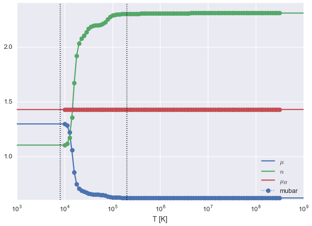

```python
tarr=np.logspace(3,9,601)
muarr_SD=np.interp(np.log10(tarr),t_SD,mu_SD)
narr_SD=np.interp(np.log10(tarr),t_SD,n_SD)
muHarr_SD=muarr_SD*narr_SD
mumin=mu_SD.min()
mumax=mu_SD.max()
plt.plot(tarr,muarr_SD,label=r'$\mu$')
plt.plot(tarr,narr_SD,label=r'$n$')
plt.plot(tarr,muHarr_SD,label=r'$\mu_H$')
lines=plt.gca().lines
plt.plot(10**t_SD,mu_SD,'o:',color=lines[0].get_color())
plt.plot(10**t_SD,n_SD,'o:',color=lines[1].get_color())
plt.plot(10**t_SD,mu_SD*n_SD,'o:',color=lines[2].get_color())
plt.axvline(8.e3,ls=':',color='k')
plt.axvline(2.e5,ls=':',color='k')
plt.legend(loc=0)
plt.xscale('log')
plt.xlabel('T [K]')
```

### Temperature calculation

1. Ideal gas law with $\gamma=5/3$. $$E \rightarrow e_{\rm int} \rightarrow P=(\gamma-1)e_{\rm int}$$
2. Our density units are $[\rho]=\mu_H m_H{\rm cm}^{-3}$ to keep dimensionless density to the hydrogen number density. But, we may want to change $\mu_H=1.4$ (KKO11; KOK13; KO15b) to $1.4271$ for consistency.
3. Simply adopt temperature dependent $\mu$ from SD93-CIE-$Z_\odot$. $$ T=\frac{\mu(T) m_H P}{\rho k_B} = \frac{\mu(T) P}{\mu_Hn_H k_B} $$
4. Let's define $T_1\equiv m_H P/\rho k_B$.
5. We now need to solve $$ f(T)\equiv T-\mu(T)T_1=0.$$ to get $T$ from any pair of $(\rho,P)$. Or, for a given $T_1$, we can find $T$ and $\mu(T)=T/T_1$.
6. I'm going to first calculate $T$ vs. $T_1$ and tabulate it. I then tabulate cooling and heating as a function of $T_1$. In the code, $T$, $\Lambda$, and $\Gamma$ can be ontained by simple piecewise linear interpolation.

```python
def calc_temp_i(T1,mumin=0.6182, mumax=1.295,toler=1.e-5):

    Tmax=mumax*T1
    Tmin=mumin*T1
    if T1 < 7.e3: return Tmax,0
    if T1 > 7.e6: return Tmin,0

    Tnew=T1
    for i in range(10):
        Told=Tnew
        Tidx=(np.log10(Told)-3)*100.

        mui=muarr_SD[Tidx]
        muip1=muarr_SD[Tidx+1]
        Ti=tarr[Tidx]
        Tip1=tarr[Tidx+1]
        dmudti=(muip1-mui)/(Tip1-Ti)

        Tnew=T1*(mui-dmudti*Ti)/(1-dmudti*T1)

        dT=abs(Told/Tnew-1)
        if dT<toler: break

    return Tnew,i



P=13000.*u.Kelvin/u.cm**3*c.k_B
rho=1.0*c.m_p/u.cm**3
T1=(P/rho/c.k_B*c.m_p).cgs.value
print T1,calc_temp_i(T1)[0]/T1
```

```
13000.0 1.07288642594
```

```python
T1arr=np.logspace(3,7,10000)
T=np.empty(10000)
imax=np.empty(10000)
for i, T1 in enumerate(T1arr):
    T[i],imax[i],=calc_temp_i(T1,toler=1.e-5)
```

```
0.618191162054 1.29497297583
```

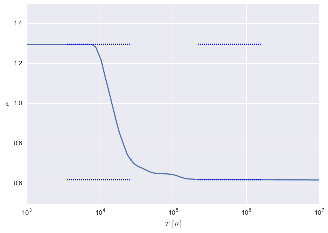

```python
print mumin,mumax
plt.semilogx(T1arr,T/T1arr)
plt.axhline(mumax,ls=':')
plt.axhline(mumin,ls=':')
plt.ylim(0.5,1.5)
plt.xlabel(r'$T_1 [K]$')
plt.ylabel(r'$\mu$')
```

## Cooling Solver

$$ \frac{de}{dt}=-\rho\mathcal{L}(\rho,T)$$

- Major collisional agents ($n_e$, $n_H$, $n_i$) may be different for low and high temperatures. But, we simply take net cooling rate as $n_H^2\Lambda(T)$ for all temperature.
- For PE heating,
  - turn off at high temperature (ionized gas). (e.g., $2\times 10^4 {\rm K}$ or $\mu < 0.7$)
  - vertical dependence? (e.g., fixed scale height for integrated value?)
  - also use $n_H\Gamma$ for convenience.
- It may be reasonable to assume that the temperature dependece of $\Gamma$ is similar to $\mu$: $$\Gamma=\Gamma_0\frac{\mu-\mu_{\rm min}}{\mu_{\rm max}-\mu_{\rm min}}+ \Gamma_{\rm CR,XR}$$
- Here, $\Gamma_0=1.8\times10^{-26} {\rm erg/s}$ and $\Gamma_{\rm CR,XR}=2\times10^{-27} {\rm erg/s}$ (to set $\Gamma=2\times10^{-26}$ for atomic gas; Koyama & Inutsuka 2002).
- We cut off the heating from $T=10^5K$.

### Implicit solver with tabulated $\Lambda$ and $\Gamma$

```python
def get_Tidx(T,Tmin=10.,Tmax=1.e9,dT=0.01,nT=801):
    if type(T)==np.ndarray:
        Tidx=np.log10(T/Tmin)/dT
        Tidx[np.where(T<Tmin)]=0
        Tidx[np.where(T>=Tmax)]=nT-2
        return Tidx.astype(int)
    else:
        if T < Tmin: return 0
        if T >= Tmax: return nT-2
        Tidx=np.log10(T/Tmin)/dT
        return int(Tidx)

def get_temp(T1,t1arr,tarr):
    T1idx=get_Tidx(T1)
    Ti=tarr[T1idx]
    Tip1=tarr[T1idx+1]
    T1i=t1arr[T1idx]
    T1ip1=t1arr[T1idx+1]
    T=Ti+(Tip1-Ti)*(T1-T1i)/(T1ip1-T1i)

    return T
def calc_temp(T1,mumin=0.6182, mumax=1.295,toler=1.e-5):

    Tmax=mumax*T1
    Tmin=mumin*T1
    if Tmax < 5.e3: return Tmax
    if Tmin > 5.e5: return Tmin

    Tnew=T1

    for i in range(10):
        Told=Tnew
        Tidx=get_Tidx(Told,Tmin=1.e3,Tmax=1.e6,dT=0.01,nT=301)

        mui=muarr_SD[Tidx]
        muip1=muarr_SD[Tidx+1]
        Ti=tarr[Tidx]
        Tip1=tarr[Tidx+1]
        dmudti=(muip1-mui)/(Tip1-Ti)

        Tnew=T1*(mui-dmudti*Ti)/(1-dmudti*T1)

        dT=abs(Told/Tnew-1)
        if dT<toler: break

    return Tnew

def cool(T):
    return lam_fit[get_Tidx(T)]
def heat(T):
    return gam_fit[get_Tidx(T)]
```

```python
import cooling
tarr=np.logspace(3,6,301)

muarr_SD=np.interp(np.log10(tarr),t_SD,mu_SD)
narr_SD=np.interp(np.log10(tarr),t_SD,n_SD)
muHarr_SD=muarr_SD*narr_SD
lam=np.array(df['log(lambda net)'])
tarr_SD=np.array(10.**t_SD)

t1arr_fit=np.logspace(1,9,801)
tarr_fit=[]
for t1 in t1arr_fit:
    tarr_fit.append(calc_temp(t1))
tarr_fit=np.array(tarr_fit)
muarr_fit=np.interp(np.log10(tarr_fit),t_SD,mu_SD)
# Set cooling function using KI02 fitting formula
lam_fit=cooling.cool(tarr_fit)
lam_SD=10.**np.interp(np.log10(tarr_fit),t_SD,lam)
# set cooling function for T>10^4.3 to SD93
idx=np.where((np.log10(tarr_fit) >4.30))
lam_fit[idx]=lam_SD[idx]
# set cooling function for T>T_max,SD using linear extrapolation
idx2=np.where(tarr_fit >tarr_SD.max())
lam_fit[idx2]=(10.**lam[-1]+(10.**lam[-1]-10.**lam[-2])/(tarr_SD[-1]-tarr_SD[-2])*(tarr_fit[idx2]-tarr_SD[-1]))

# set heatting function
gam_fit=1.8e-26*(muarr_fit-mumin)/(mumax-mumin)+2.e-27
# cutoff heating fuction for T>10^5
idx=tarr_fit >1.e5
gam_fit[idx]=gam_fit[idx]*np.exp(-tarr_fit[idx]/1.e5+1)
idx=gam_fit < 1.e-30
gam_fit[idx]=0.0
```

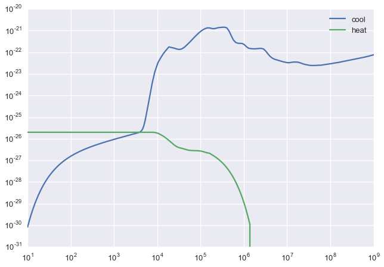

```python
#save the tabulated results.
coolftn={'cool':lam_fit, 'heat':gam_fit, 'temp':tarr_fit, 't1':t1arr_fit}
import cPickle as p
#using standard pickle
p.dump(coolftn,open('coolftn.p','wb'),p.HIGHEST_PROTOCOL)
#using pandas
cooldf=pd.DataFrame(coolftn,index=t1arr_fit)
cooldf.to_pickle('coolftn_df.p')
cooldf.plot(y=['cool','heat'],logx=True,logy=True)
```

### to get temperature from simulation data

- download tabulated results

```python
# restore tabulated data
cdf=p.load(open('coolftn.p','rb'))
print cdf.keys()
```

```
['heat', 'cool', 'temp', 't1']
```

```python
def get_Tidx(T,Tmin=10.,Tmax=1.e9,dT=0.01,nT=801):
    if type(T)==np.ndarray:
        Tidx=np.log10(T/Tmin)/dT
        Tidx[np.where(T<Tmin)]=0
        Tidx[np.where(T>=Tmax)]=nT-2
        return Tidx.astype(int)
    else:
        if T < Tmin: return 0
        if T >= Tmax: return nT-2
        Tidx=np.log10(T/Tmin)/dT
        return int(Tidx)

def get_data(cdf,T1,field='temp'):
    T1idx=get_Tidx(T1)
    Ti=cdf[field][T1idx]
    Tip1=cdf[field][T1idx+1]
    T1i=cdf['t1'][T1idx]
    T1ip1=cdf['t1'][T1idx+1]
    T=Ti+(Tip1-Ti)*(T1-T1i)/(T1ip1-T1i)

    return T
```

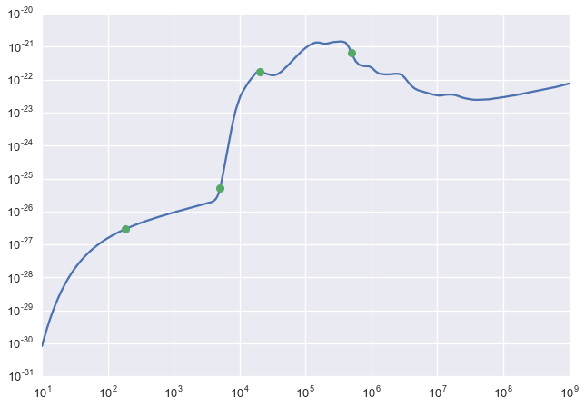

```python
plt.loglog(cdf['t1'],cdf['cool'])
T1=np.array([184,5050,2.e4,5.e5])
plt.plot(T1,get_data(cdf,T1,'cool'),'o')
```